# Clustering For English Movies, The data source: IMDB

Marco Ayuob

2024-01-12

## Introduction

In this project, we will be delving into the fascinating world of movies. Our goal is to explore patterns and relationships within a diverse dataset that contains information such as budget, release year, user ratings, and genre. By utilizing clustering techniques, we aim to uncover natural groupings and similarities among movies. This will not only be beneficial for the audience but also for the producers.

- The data source is from IMDB

## Data Exploration and Cleaning:

- To begin, establish the directory where you will be working and  
  proceed to load the dataset for the movie.
- Please perform a thorough analysis of the dataset by examining its summary statistics and structural characteristics.
- To maintain the accuracy and consistency of the data, it is crucial to convert the relevant columns into numeric data types and address any missing values. This can help in ensuring the reliability and  
  usefulness of the data for analysis and decision-making purposes.

```r
# Set the working directory and read the file
movies_AR <- read.csv("/Users/marcoayuob/Downloads/Data science /1st Year/Unsupervised Learning/Clustering Project/CL_draft.csv")
```

```r
# Display summary information and structure of the dataset
summary(movies_AR)
```

```
##      Budget            Language           Country               Year
##  Min.   :   100000   Length:5737        Length:5737        Min.   :1991
##  1st Qu.:  5000000   Class :character   Class :character   1st Qu.:2001
##  Median : 18000000   Mode  :character   Mode  :character   Median :2007
##  Mean   : 30751907                                         Mean   :2006
##  3rd Qu.: 39000000                                         3rd Qu.:2012
##  Max.   :380000000                                         Max.   :2017
##      Name                Rate           Genre
##  Length:5737        Min.   : 0.000   Length:5737
##  Class :character   1st Qu.: 5.300   Class :character
##  Mode  :character   Median : 6.000   Mode  :character
##                     Mean   : 5.864
##                     3rd Qu.: 6.600
##                     Max.   :10.000
```

```r
str(movies_AR)
```

```
## 'data.frame':    5737 obs. of  7 variables:
##  $ Budget  : int  30000000 200000 250000 300000 500000 800000 800000 1000000 1182273 1227401 ...
##  $ Language: chr  "en" "en" "en" "en" ...
##  $ Country : chr  "United States of America" "United States of America" "United States of America" "United States of America" ...
##  $ Year    : int  1991 1991 1991 1991 1991 1991 1991 1991 1991 1991 ...
##  $ Name    : chr  "Madonna: Truth or Dare" "Dingo" "Poison" "High Strung" ...
##  $ Rate    : num  6.3 6 6.4 5.4 4.8 6.8 6 4.8 4.2 6.4 ...
##  $ Genre   : chr  "Documentary" "Drama" "Drama" "Comedy" ...
```

```r
# Convert certain columns to numeric data types
movies_AR$Budget <- as.numeric(as.character(movies_AR$Budget))
movies_AR$Year <- as.numeric(as.character(movies_AR$Year))
movies_AR$Rate <- as.numeric(as.character(movies_AR$Rate))
```

```r
# Checking for missing values in the dataset and handling them
colSums(is.na(movies_AR))
```

```
##   Budget Language  Country     Year     Name     Rate    Genre
##        0        0        0        0        0        0        0
```

```r
movies_AR <- na.omit(movies_AR)
movies_AR$Genre[is.na(movies_AR$Genre)] <- NA
movies_AR$Budget[is.na(movies_AR$Budget)] <- mean(movies_AR$Budget)
```

```r
# Remove rows with empty Genre
movies_AR <- movies_AR[movies_AR$Genre != "", ]
```

## Statistical values and plots before clustering

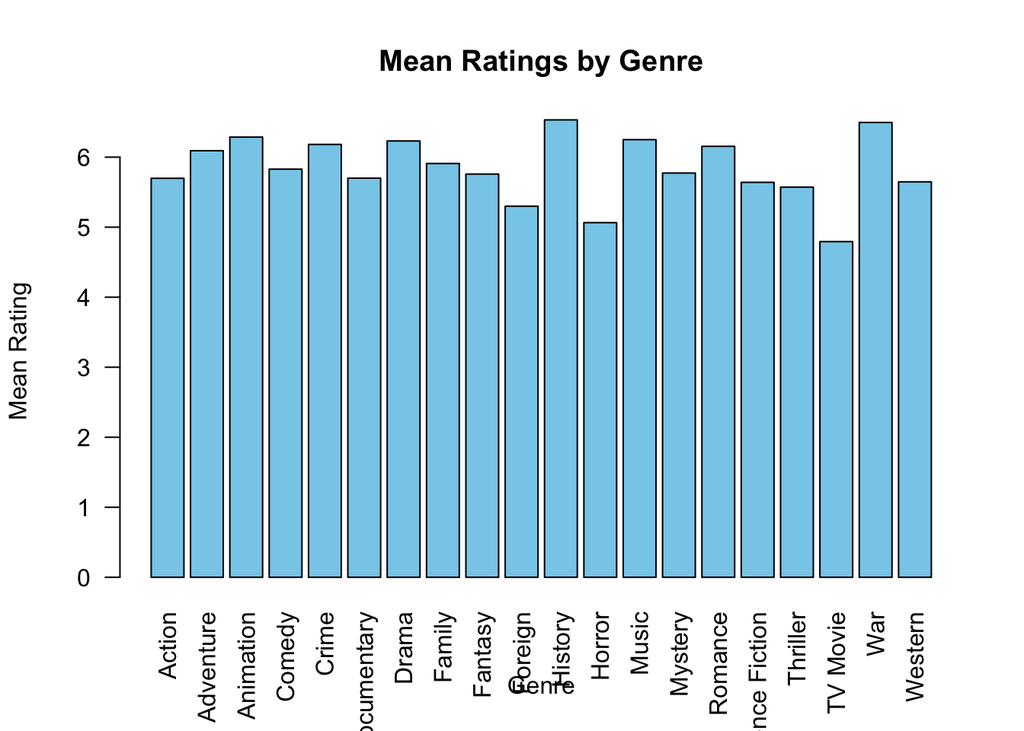

```r
# Calculating mean ratings by genre and create a bar plot to visualize them
mean_ratings <- aggregate(Rate ~ Genre, data = movies_AR, FUN = mean, na.rm = TRUE)
barplot(mean_ratings$Rate, names.arg = mean_ratings$Genre,
        col = "skyblue", xlab = "Genre", ylab = "Mean Rating",
        main = "Mean Ratings by Genre", las = 2)
```

we can see from this plot the mean (Average) rating for every Genre

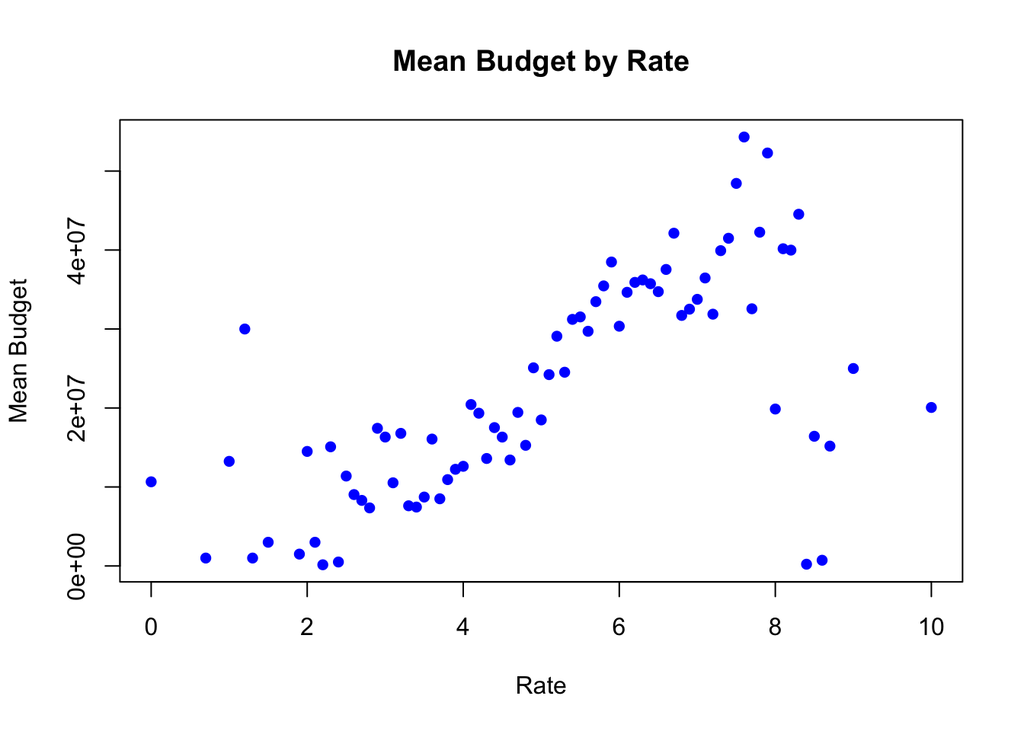

```r
# Calculate mean budget by rate and create a scatter plot to visualize them
mean_budget <- aggregate(Budget ~ Rate, data = movies_AR, FUN = mean, na.rm = TRUE)
plot(mean_budget$Rate, mean_budget$Budget,
     xlab = "Rate", ylab = "Mean Budget",
     main = "Mean Budget by Rate", col = "blue", pch = 16)
```

from the previous plot we can observe that from rate 6 to 8 are the movies that have the highest budget (production coast)

```r
# Calculating the movies with the maximum rating and corresponding year(s)
max_rating <- max(movies_AR$Rate)
years_highest_rating <- unique(movies_AR$Year[movies_AR$Rate == max_rating])
years_highest_rating
```

```
## [1] 1998 2002 2006 2010 2012
```

those are the years that have highest rate of movies

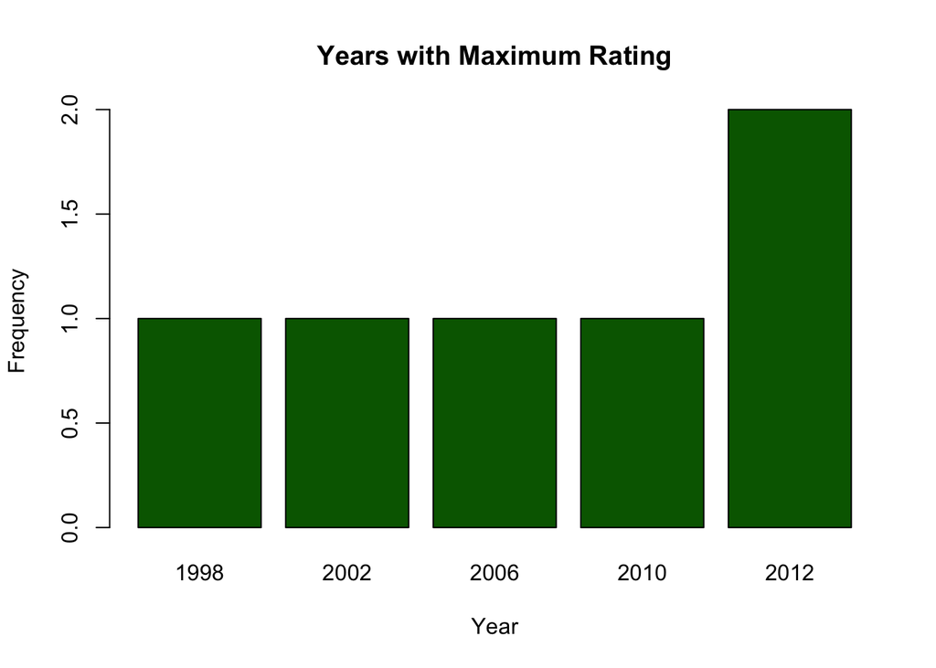

```r
# Bar plot for years with maximum rating
barplot(table(movies_AR$Year[movies_AR$Rate == max_rating]),
        xlab = "Year", ylab = "Frequency",
        main = "Years with Maximum Rating", col = "darkgreen")
```